# Problema 1 - Checkpoint 4 AD1 UFCG

Diogo Florêncio

```r
library(tidyr)
library(dplyr)
library(ggplot2)
dados <- read.csv("series_from_imdb.csv",encoding="UTF-8")
```

# Qual a melhor série?

A melhor série deve ter episódios bem avaliados, além de manter regularidade na avaliação. Seguindo esses critérios, o gráfico exibe a relacação entre mediana e variância para nota dos episódios de cada série. Quanto mais acima a série está melhor é sua avaliação, quanto mais a esquerda está mais regular é.

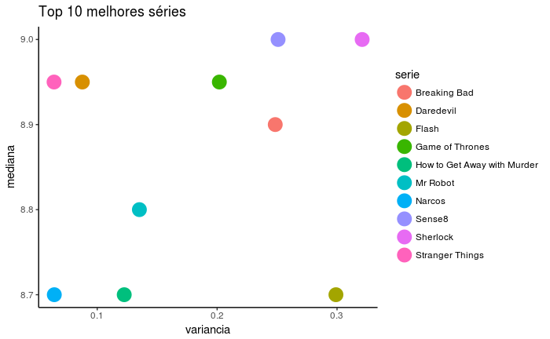

```r
dados %>%
    group_by(serie = series_name) %>%
    summarise(mediana = median(UserRating),
              variancia = var(UserRating)) %>%
    arrange(desc(mediana),variancia)%>%
    slice(1:10) %>%
  ggplot(aes(x = variancia, y = mediana, color = serie)) +
  geom_point(size = 6) +
  theme_classic() +
  ggtitle("Top 10 melhores séries")
```

As melhores séries devem estar localizadas acima e a esquerda. Sherlock e Sense8 possuem as melhores avaliações, porém apresentam uma irregularidade maior que as demais. Deste modo Stranger Things e Daredevil podem ser consideradas como as melhores séries, por equilibrarem boa avaliação e regularidade.

### As melhores séries tem muitos episódios?

Uma série com poucos episódios teria mais chances de manter a regularidade e boa avaliação dos episódios? Afim de repsonder a pergunta, o gráfico exibe a relacação entre mediana, variância e quantidade, para os episódios de cada série. Os pontos mais acima e a esquerda referenciam as melhores séries. Quanto maior for o ponto mais episódios a série tem.

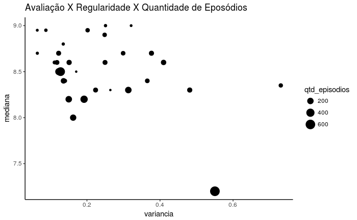

```r
dados %>%
    group_by(serie = series_name) %>%
    summarise(mediana = median(UserRating),
              variancia = var(UserRating),
              qtd_episodios = n()) %>%
  ggplot(aes(x = variancia, y = mediana, size = qtd_episodios)) +
  geom_point() +
  theme_classic() +
  ggtitle("Avaliação X Regularidade X Quantidade de Eposódios")
```

Os pontos mais acima a a esquerda são as melhores séries, neste setor do gráfico os pontos são menores indicando que as melhores séries não tem muitos episódios.

# Qual a melhor temporada?

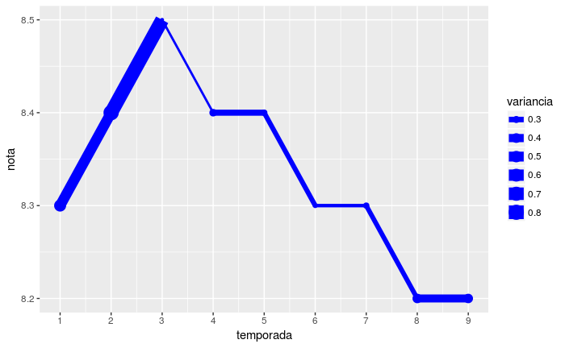

```r
dados %>%
  group_by(temporada = season)%>%
  summarise(nota = median(UserRating),
            variancia = var(UserRating))%>%
  ggplot(aes(x = temporada, y = nota, size = variancia)) +
  geom_line(color = "blue") +
  geom_point(color = "blue") +
  scale_x_continuous(breaks=seq(0, 10, 1))
```

### Qual temporada tem mais episódios?

A temporada com mais episódios, pode sugerir qual será a temporada mais extensa de uma série. O gráfico exibe a quantidade de episódios ao longo das temporadas, considerando todas séries.

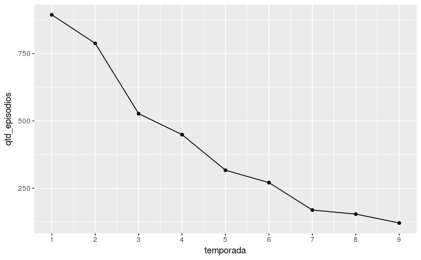

```r
dados %>%
  group_by(temporada = season)%>%
  summarise(qtd_episodios = n())%>%
  ggplot(aes(x = temporada, y = qtd_episodios)) +
  geom_line() +
  geom_point() +
  scale_x_continuous(breaks=seq(0, 10, 1))
```

A quantidade de episódios decresce ao longo das temporadas. Deste modo, a primeira temporada tende a ser a mais extensa para maioria das séries.